1 /

← Part 2: RPart 3: LaTeX

Part 3 of 3

# LaTeX

Typesetting documents by writing, not clicking. 22 slides from a blank file to your first properly structured document.

[Overleaf's full tutorial](https://www.overleaf.com/learn/latex/Learn_LaTeX_in_30_minutes) [Try it online (Overleaf)](https://www.overleaf.com/)

Use → / click Next to begin

Concepts

## What Is LaTeX?

Most word processors are **WYSIWYG** — what you see is what you get. You click, drag, and format a page directly, and the tool shows you the result as you go.

LaTeX works the opposite way. You write a plain text file full of commands that describe *what things are* — a section, a table, an equation — not how they should look pixel-by-pixel. A program called a **TeX engine** then reads that file and compiles it into a finished PDF.

The upshot: you focus on content and structure, and LaTeX handles the visual formatting for you, consistently, every time.

Concepts

## Why Learn LaTeX?

- Handles complex math, technical notation, and large tables far more gracefully than a word processor.
- Numbers figures, equations, citations, and table-of-contents entries automatically — renumber freely without breaking anything.
- Separates content from style: rewrite what a document looks like without touching a word of what it says.
- Extensible through thousands of free, community-written packages.

It's not the right tool for everything — free-form magazine-style layouts are still easier in a visual design tool. But for anything technical, academic, or reference-heavy, it earns its learning curve fast.

Your First Document

## Documentclass & Body

main.tex

```
\documentclass{article}
\begin{document}
This is my first document. It has no extra
styling applied yet, and LaTeX has already
indented this paragraph automatically.
\end{document}
```

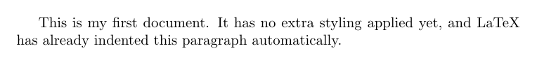

rendered PDF

`\documentclass` sets the document type. Everything between `\begin{document}` and `\end{document}` is the body — the part that actually gets typeset.

Structure

## The Preamble

Everything *before* `\begin{document}` is called the **preamble** — the document's setup section.

preamble

```
\documentclass[12pt, a4paper]{article}
\usepackage{amsmath}
```

- Options inside `[...]` configure the class — here, 12-point type on A4 paper.
- `\usepackage{...}` loads extra functionality — more on packages in a few slides.

Structure

## Title, Author & Date

main.tex

```
\documentclass[12pt, letterpaper]{article}
\title{Notes on Typesetting}
\author{Ada Lovelace}
\date{\today}
\begin{document}
\maketitle
A title, author, and date now appear above
this text, generated automatically by
\maketitle.
\end{document}
```

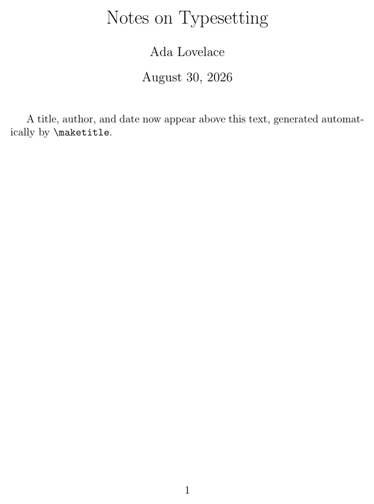

rendered PDF

`\date{\today}` inserts the actual compile date automatically, every single time you rebuild the document.

Structure

## Comments

main.tex

```
% Everything after a percent sign is ignored.
% Use comments for to-do notes, explanations,
% or to disable a line while debugging.
\documentclass{article}
```

A `%` at the start of a line — or anywhere mid-line — comments out everything after it. Nothing after a `%` gets typeset.

Formatting

## Bold, Italic & Underline

main.tex

```
Some ideas are \textbf{bold}, some
are \textit{subtle}, and some
deserve \underline{extra attention}.
```

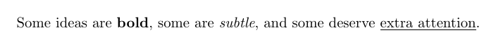

rendered PDF

There's also `\emph{...}`, which adapts to context: italic inside upright text, but it flips to upright if you're already inside an italicized block.

Formatting

## Lists

main.tex

```
\begin{itemize}
  \item First point
  \item Second point
\end{itemize}

\begin{enumerate}
  \item Step one
  \item Step two
\end{enumerate}
```

[figure not shown]

rendered PDF

`itemize` gives bullets, `enumerate` gives automatic numbering — same `\item` syntax either way.

Media

## Adding Images

Importing a graphic needs the `graphicx` package, loaded in the preamble:

main.tex

```
\usepackage{graphicx}
\graphicspath{{figures/}}

\includegraphics[width=0.75\textwidth]{diagram}
```

- `\graphicspath` tells LaTeX which folder to look in.
- Give the filename without its extension — LaTeX searches supported formats for you.
- `width=0.75\textwidth` scales the image relative to the text column, not an absolute size.

Media

## Captions, Labels & Cross-References

main.tex

```
\begin{figure}[h]
  \centering
  \includegraphics[width=0.6\textwidth]{diagram}
  \caption{A labeled diagram.}
  \label{fig:diagram}
\end{figure}

See Figure~\ref{fig:diagram} on
page~\pageref{fig:diagram}.
```

`\label` + `\ref` is the whole trick: LaTeX tracks the actual figure number for you. Reorder or insert figures freely — every reference updates itself on the next compile.

Math

## Math Mode: Inline vs. Display

main.tex

```
Inline: Einstein's relation
$E=mc^2$ sits right in a sentence.

Display:
\[ \int_0^1 x^2\,dx = \frac{1}{3} \]

Greek and subscripts:
$\alpha$, $\beta$, $\Omega$, $x_i^2$
```

[figure not shown]

rendered PDF

Single `$...$` keeps math inline with text. `\[...\]` centers an equation on its own line — prefer it over the old-style `$$...$$`, which modern LaTeX advises against.

Math

## Common Math Building Blocks

| Want | Write |
| --- | --- |
| Fraction | `\frac{a}{b}` |
| Subscript / superscript | `a_b` / `a^b` |
| Square root | `\sqrt{x}` |
| Integral | `\int_0^1 ... \, dx` |
| Summation | `\sum_{i=1}^n` |
| Greek letters | `\alpha \beta \Omega` |
| Named functions | `\sin \cos \log` |

All of these work inside either `$...$` or `\[...\]`. Named functions like `\sin` matter — plain `sin(x)` renders italicized as if it were three separate variables multiplied together.

Document Structure

## Sections & Chapters

main.tex

```
\section{Introduction}
This is the opening section.

\subsection{A Finer Point}
Subsections nest one level deeper.

\section*{A Note}
Starred sections skip numbering.
```

[figure not shown]

rendered PDF

`\chapter` and `\part` only exist in the `report` and `book` classes — `article` tops out at `\section`. Numbering is automatic unless you use the starred (`*`) form.

Document Structure

## Paragraphs & Line Breaks

main.tex

```
First paragraph.

Second paragraph starts after a blank line.

Third paragraph continues on\\
a manual new line, same paragraph.
```

- A blank line starts a new paragraph — LaTeX indents it automatically.
- `\\` (or `\newline`) breaks the line without starting a new paragraph.

Avoid stacking `\\\\` to fake extra spacing between paragraphs — it fights LaTeX's own spacing rules. Use the `parskip` package instead if you want visible gaps.

Tables

## Building a Table

main.tex

```
\begin{tabular}{|l|c|c|}
\hline
Language & First Released & Typed \\
\hline
Bash & 1989 & No \\
R & 1993 & Weakly \\
LaTeX & 1985 & --- \\
\hline
\end{tabular}
```

[figure not shown]

rendered PDF

`{|l|c|c|}` declares three columns (left/center/center-aligned) with vertical rules between them. `&` separates cells, `\\` ends a row, and `\hline` draws a horizontal rule.

Document Structure

## Table of Contents

main.tex

```
\tableofcontents

\section{Background}
...
\section{Findings}
...
```

One command builds and numbers the entire table of contents from whatever `\section`/`\subsection` commands already exist in your document. Compile twice — the first pass collects the section numbers and page numbers, the second pass writes them into the contents page.

Packages

## Loading Packages & Options

main.tex

```
\usepackage{geometry}
\usepackage[margin=1in]{geometry}
```

Options inside `[...]` configure a package's behavior — here, setting every page margin to 1 inch. Without options, a package just loads with its defaults.

If LaTeX can't find the package's underlying `.sty` file, it stops with a clear "file not found" error rather than silently failing.

Packages

## Finding Packages: CTAN & TeX Live

**CTAN** (the Comprehensive TeX Archive Network) hosts thousands of free, community-contributed packages covering everything from chemistry notation to chess diagrams.

**TeX Live** bundles a large, tested snapshot of CTAN into one installable distribution, refreshed annually. Overleaf, and most desktop LaTeX installs, run on TeX Live — so a package can exist on CTAN without yet being available to you if it's very new or has licensing/platform quirks.

[Browse CTAN](https://ctan.org/) [About TeX Live](https://tug.org/texlive/)

Reference

## Cheat Sheet

| Command | Does |
| --- | --- |
| `\documentclass{article}` | Sets the document type |
| `\usepackage{name}` | Loads extra functionality |
| `\section{...}` | Numbered heading |
| `\textbf{} \textit{}` | Bold / italic |
| `itemize` / `enumerate` | Bulleted / numbered list |
| `$...$` / `\[...\]` | Inline / display math |
| `tabular` | Table environment |
| `\label` / `\ref` | Cross-reference anything |
| `\tableofcontents` | Auto-generated contents page |

Keep Going

## Where to Go Next

This deck covers the same ground as Overleaf's own free introduction, condensed and restructured as slides — their version has more detail on every topic and is worth reading end to end.

[Overleaf: Learn LaTeX in 30 minutes](https://www.overleaf.com/learn/latex/Learn_LaTeX_in_30_minutes) [Overleaf documentation home](https://www.overleaf.com/learn)

Beyond the basics: bibliography management (`biblatex`/`bibtex`), the `Beamer` class for building actual slide presentations in LaTeX itself, and `TikZ` for drawing diagrams directly in your document.

Series Complete

# Bash → R → LaTeX

All three parts of the course are now live.

← Part 1: Bash Scripting ← Part 2: R Programming